# Ford GoBike Dataset

## by Caio Vasconcelos Silva Andrade

## Preliminary Wrangling

> This notebook explores a dataset about the Ford Gobike system, a bike-sharing system covering the greater San Francisco Bay area, now know as Bay Wheels, the dataset counts with 183412 values with features like gender, stations name and other ones

```python
import pandas as pd
import numpy as np
import matplotlib.pyplot as plt
import seaborn as sns

%matplotlib inline
%config InlineBackend.figure_format = 'retina'
```

```python
fonte = '201902-fordgobike-tripdata.csv'
df = pd.read_csv(fonte)
```

```python
print(df.shape)
df.head(3)
```

```
(183412, 16)
```

|  | duration_sec | start_time | end_time | start_station_id | start_station_name | start_station_latitude | start_station_longitude | end_station_id | end_station_name | end_station_latitude | end_station_longitude | bike_id | user_type | member_birth_year | member_gender | bike_share_for_all_trip |
| --- | --- | --- | --- | --- | --- | --- | --- | --- | --- | --- | --- | --- | --- | --- | --- | --- |
| 0 | 52185 | 2019-02-28 17:32:10.1450 | 2019-03-01 08:01:55.9750 | 21.0 | Montgomery St BART Station (Market St at 2nd St) | 37.789625 | -122.400811 | 13.0 | Commercial St at Montgomery St | 37.794231 | -122.402923 | 4902 | Customer | 1984.0 | Male | No |
| 1 | 42521 | 2019-02-28 18:53:21.7890 | 2019-03-01 06:42:03.0560 | 23.0 | The Embarcadero at Steuart St | 37.791464 | -122.391034 | 81.0 | Berry St at 4th St | 37.775880 | -122.393170 | 2535 | Customer | NaN | NaN | No |
| 2 | 61854 | 2019-02-28 12:13:13.2180 | 2019-03-01 05:24:08.1460 | 86.0 | Market St at Dolores St | 37.769305 | -122.426826 | 3.0 | Powell St BART Station (Market St at 4th St) | 37.786375 | -122.404904 | 5905 | Customer | 1972.0 | Male | No |

```python
df.info()
```

```
<class 'pandas.core.frame.DataFrame'>
RangeIndex: 183412 entries, 0 to 183411
Data columns (total 16 columns):
 #   Column                   Non-Null Count   Dtype
---  ------                   --------------   -----
 0   duration_sec             183412 non-null  int64
 1   start_time               183412 non-null  object
 2   end_time                 183412 non-null  object
 3   start_station_id         183215 non-null  float64
 4   start_station_name       183215 non-null  object
 5   start_station_latitude   183412 non-null  float64
 6   start_station_longitude  183412 non-null  float64
 7   end_station_id           183215 non-null  float64
 8   end_station_name         183215 non-null  object
 9   end_station_latitude     183412 non-null  float64
 10  end_station_longitude    183412 non-null  float64
 11  bike_id                  183412 non-null  int64
 12  user_type                183412 non-null  object
 13  member_birth_year        175147 non-null  float64
 14  member_gender            175147 non-null  object
 15  bike_share_for_all_trip  183412 non-null  object
dtypes: float64(7), int64(2), object(7)
memory usage: 22.4+ MB
```

```python
df.describe()
```

|  | duration_sec | start_station_id | start_station_latitude | start_station_longitude | end_station_id | end_station_latitude | end_station_longitude | bike_id | member_birth_year |
| --- | --- | --- | --- | --- | --- | --- | --- | --- | --- |
| count | 183412.000000 | 183215.000000 | 183412.000000 | 183412.000000 | 183215.000000 | 183412.000000 | 183412.000000 | 183412.000000 | 175147.000000 |
| mean | 726.078435 | 138.590427 | 37.771223 | -122.352664 | 136.249123 | 37.771427 | -122.352250 | 4472.906375 | 1984.806437 |
| std | 1794.389780 | 111.778864 | 0.099581 | 0.117097 | 111.515131 | 0.099490 | 0.116673 | 1664.383394 | 10.116689 |
| min | 61.000000 | 3.000000 | 37.317298 | -122.453704 | 3.000000 | 37.317298 | -122.453704 | 11.000000 | 1878.000000 |
| 25% | 325.000000 | 47.000000 | 37.770083 | -122.412408 | 44.000000 | 37.770407 | -122.411726 | 3777.000000 | 1980.000000 |
| 50% | 514.000000 | 104.000000 | 37.780760 | -122.398285 | 100.000000 | 37.781010 | -122.398279 | 4958.000000 | 1987.000000 |
| 75% | 796.000000 | 239.000000 | 37.797280 | -122.286533 | 235.000000 | 37.797320 | -122.288045 | 5502.000000 | 1992.000000 |
| max | 85444.000000 | 398.000000 | 37.880222 | -121.874119 | 398.000000 | 37.880222 | -121.874119 | 6645.000000 | 2001.000000 |

##### Change to daytime

```python
# Quick change o variables time, to daytime
df["start_time"] = pd.to_datetime(df["start_time"])
df["end_time"] = pd.to_datetime(df["end_time"])
```

```python
df.info()
```

```
<class 'pandas.core.frame.DataFrame'>
RangeIndex: 183412 entries, 0 to 183411
Data columns (total 16 columns):
 #   Column                   Non-Null Count   Dtype
---  ------                   --------------   -----
 0   duration_sec             183412 non-null  int64
 1   start_time               183412 non-null  datetime64[ns]
 2   end_time                 183412 non-null  datetime64[ns]
 3   start_station_id         183215 non-null  float64
 4   start_station_name       183215 non-null  object
 5   start_station_latitude   183412 non-null  float64
 6   start_station_longitude  183412 non-null  float64
 7   end_station_id           183215 non-null  float64
 8   end_station_name         183215 non-null  object
 9   end_station_latitude     183412 non-null  float64
 10  end_station_longitude    183412 non-null  float64
 11  bike_id                  183412 non-null  int64
 12  user_type                183412 non-null  object
 13  member_birth_year        175147 non-null  float64
 14  member_gender            175147 non-null  object
 15  bike_share_for_all_trip  183412 non-null  object
dtypes: datetime64[ns](2), float64(7), int64(2), object(5)
memory usage: 22.4+ MB
```

```python
df.columns
```

```
Index(['duration_sec', 'start_time', 'end_time', 'start_station_id',
       'start_station_name', 'start_station_latitude',
       'start_station_longitude', 'end_station_id', 'end_station_name',
       'end_station_latitude', 'end_station_longitude', 'bike_id', 'user_type',
       'member_birth_year', 'member_gender', 'bike_share_for_all_trip'],
      dtype='object')
```

##### Creating a column with the weekdays of the rental

```python
df['start_time'].dt.dayofweek.value_counts()
```

```
3    35197
1    31813
2    29641
4    28981
0    26852
6    15523
5    15405
Name: start_time, dtype: int64
```

```python
weekday = []

for i in df['start_time'].dt.dayofweek:
    if i == 0:
        weekday.append('Monday')
    elif i == 1:
        weekday.append('Tuesday')
    elif i == 2:
        weekday.append('Wednesday')
    elif i == 3:
        weekday.append('Thursday')
    elif i == 4:
        weekday.append('Friday')
    elif i == 5:
        weekday.append('Saturday')
    elif i == 6:
        weekday.append('Sunday')
```

```python
a = np.array(weekday)
```

```python
a = pd.Series(a)
```

```python
a.value_counts().sum()
```

```
183412
```

```python
df['start_weekday'] = a
```

```python
df.head(3)
```

|  | duration_sec | start_time | end_time | start_station_id | start_station_name | start_station_latitude | start_station_longitude | end_station_id | end_station_name | end_station_latitude | end_station_longitude | bike_id | user_type | member_birth_year | member_gender | bike_share_for_all_trip | start_weekday |
| --- | --- | --- | --- | --- | --- | --- | --- | --- | --- | --- | --- | --- | --- | --- | --- | --- | --- |
| 0 | 52185 | 2019-02-28 17:32:10.145 | 2019-03-01 08:01:55.975 | 21.0 | Montgomery St BART Station (Market St at 2nd St) | 37.789625 | -122.400811 | 13.0 | Commercial St at Montgomery St | 37.794231 | -122.402923 | 4902 | Customer | 1984.0 | Male | No | Thursday |
| 1 | 42521 | 2019-02-28 18:53:21.789 | 2019-03-01 06:42:03.056 | 23.0 | The Embarcadero at Steuart St | 37.791464 | -122.391034 | 81.0 | Berry St at 4th St | 37.775880 | -122.393170 | 2535 | Customer | NaN | NaN | No | Thursday |
| 2 | 61854 | 2019-02-28 12:13:13.218 | 2019-03-01 05:24:08.146 | 86.0 | Market St at Dolores St | 37.769305 | -122.426826 | 3.0 | Powell St BART Station (Market St at 4th St) | 37.786375 | -122.404904 | 5905 | Customer | 1972.0 | Male | No | Thursday |

##### Final cleaning

```python
# I saw that existed some entries with year 1900, so i dropped all the values <= 1930
df.drop(df.query('member_birth_year <= 1930').index , inplace = True)
```

```python
df.info()
```

```
<class 'pandas.core.frame.DataFrame'>
Int64Index: 183334 entries, 0 to 183411
Data columns (total 17 columns):
 #   Column                   Non-Null Count   Dtype
---  ------                   --------------   -----
 0   duration_sec             183334 non-null  int64
 1   start_time               183334 non-null  datetime64[ns]
 2   end_time                 183334 non-null  datetime64[ns]
 3   start_station_id         183137 non-null  float64
 4   start_station_name       183137 non-null  object
 5   start_station_latitude   183334 non-null  float64
 6   start_station_longitude  183334 non-null  float64
 7   end_station_id           183137 non-null  float64
 8   end_station_name         183137 non-null  object
 9   end_station_latitude     183334 non-null  float64
 10  end_station_longitude    183334 non-null  float64
 11  bike_id                  183334 non-null  int64
 12  user_type                183334 non-null  object
 13  member_birth_year        175069 non-null  float64
 14  member_gender            175069 non-null  object
 15  bike_share_for_all_trip  183334 non-null  object
 16  start_weekday            183334 non-null  object
dtypes: datetime64[ns](2), float64(7), int64(2), object(6)
memory usage: 25.2+ MB
```

### What is/are the main feature(s) of interest in your dataset?

> The main features of interest at least for me are: age, user type, gender, start and end station

### What features in the dataset do you think will help support your investigation into your feature(s) of interest?

> Probably user_type, age, and gender will have effects on trip duration, stations and someother things. The dataset is about the San Francisco Area...i have never been to San Frasisco so maybe some research from my part about the stations names, just to see with they are really crowded or if there a University nearby...things like that!

## Univariate Exploration

### Gender

```
Male      130590
Female     40830
Other       3649
Name: member_gender, dtype: int64
```

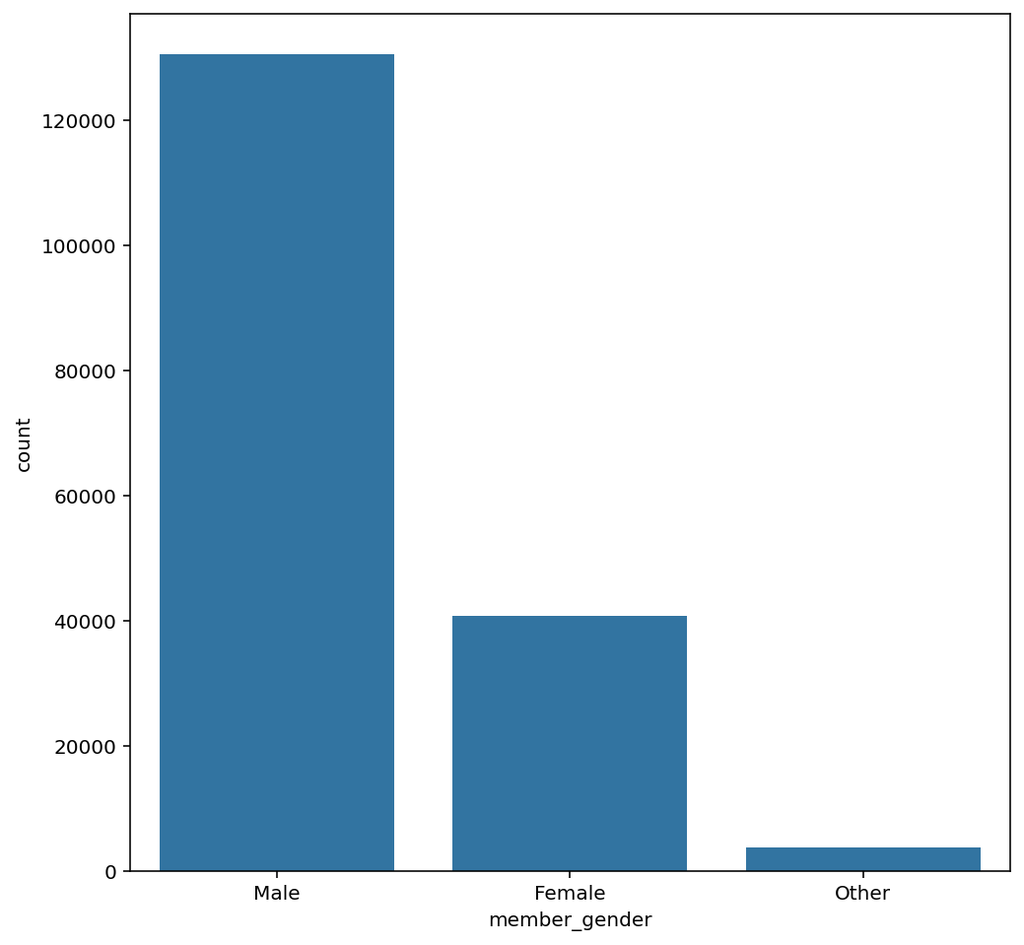

```python
print(df['member_gender'].value_counts())
plt.figure(figsize = (8,8))
sns.countplot(data = df, x = 'member_gender', order = df['member_gender'].value_counts().index, color = sns.color_palette()[0]);
```

- Just a gender count, to see the gender distribution

### Subscription

```
Subscriber    163473
Customer       19861
Name: user_type, dtype: int64
```

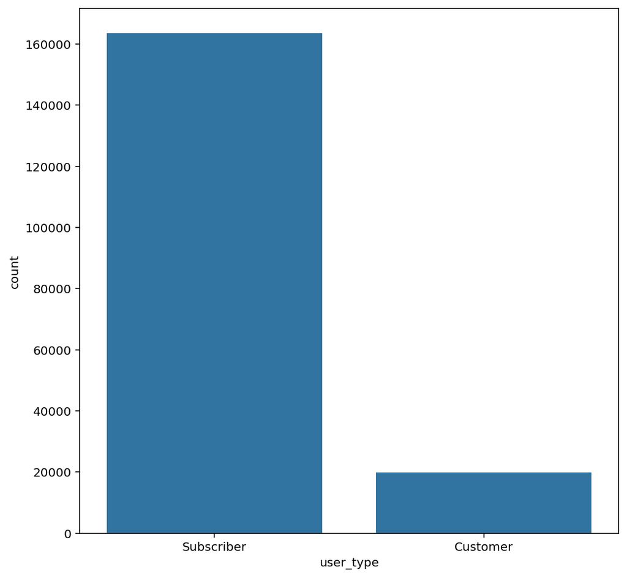

```python
print(df['user_type'].value_counts())
plt.figure(figsize = (8,8))
sns.countplot(data = df, x = 'user_type', order = df['user_type'].value_counts().index, color = sns.color_palette()[0]);
```

- Samething for the Subscription

### Day of the week

```python
df['start_weekday'].value_counts().index
```

```
Index(['Thursday', 'Tuesday', 'Wednesday', 'Friday', 'Monday', 'Sunday',
       'Saturday'],
      dtype='object')
```

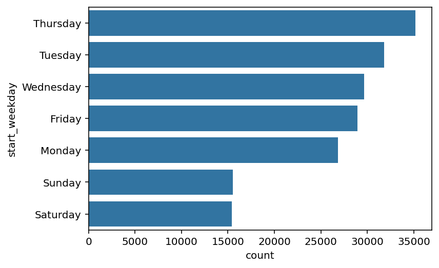

```python
# 0 Monday 6 Sunday
sns.countplot(data = df, y = 'start_weekday', order = df['start_weekday'].value_counts().index, color = sns.color_palette()[0]);
#plt.xticks()
```

- Days of the week if the highest number of bike rents

### Age

```python
len(df["member_birth_year"].value_counts())
```

```
66
```

```python
np.arange(1931, df['member_birth_year'].max() + 9, 9)
```

```
array([1931., 1940., 1949., 1958., 1967., 1976., 1985., 1994., 2003.])
```

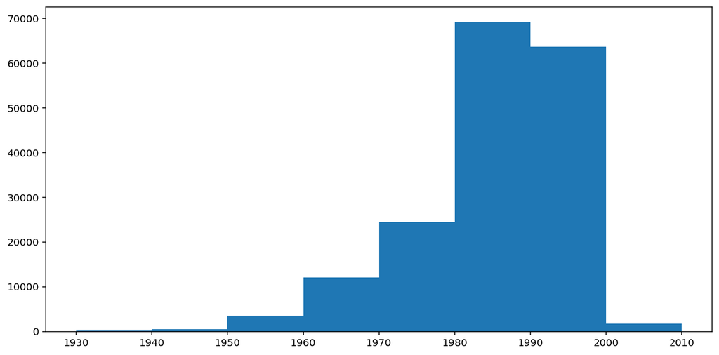

```python
plt.figure(figsize = (12,6))
bins =np.arange(1930, df['member_birth_year'].max() + 10, 10)
plt.hist(df['member_birth_year'], bins = bins);
```

- A histogram with the age counts, we can see that most of the users have ages between 21 to 41 (taking 2021 as consideration)

```python
df['member_birth_year'].describe()
```

```
count    175069.000000
mean       1984.843302
std           9.965890
min        1931.000000
25%        1980.000000
50%        1987.000000
75%        1992.000000
max        2001.000000
Name: member_birth_year, dtype: float64
```

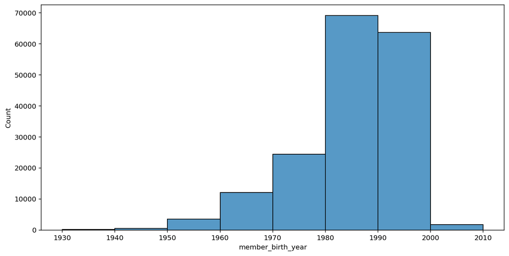

```python
plt.figure(figsize = (12,6))
sns.histplot(data = df, x = 'member_birth_year', binrange = [1930, 2001], binwidth = 10);
```

- Just another way of plotting it

### Start Station

```
Market St at 10th St                                         3904
San Francisco Caltrain Station 2  (Townsend St at 4th St)    3542
Berry St at 4th St                                           3051
Montgomery St BART Station (Market St at 2nd St)             2893
Powell St BART Station (Market St at 4th St)                 2760
San Francisco Ferry Building (Harry Bridges Plaza)           2709
San Francisco Caltrain (Townsend St at 4th St)               2698
Powell St BART Station (Market St at 5th St)                 2327
Howard St at Beale St                                        2293
Steuart St at Market St                                      2283
Name: start_station_name, dtype: int64
```

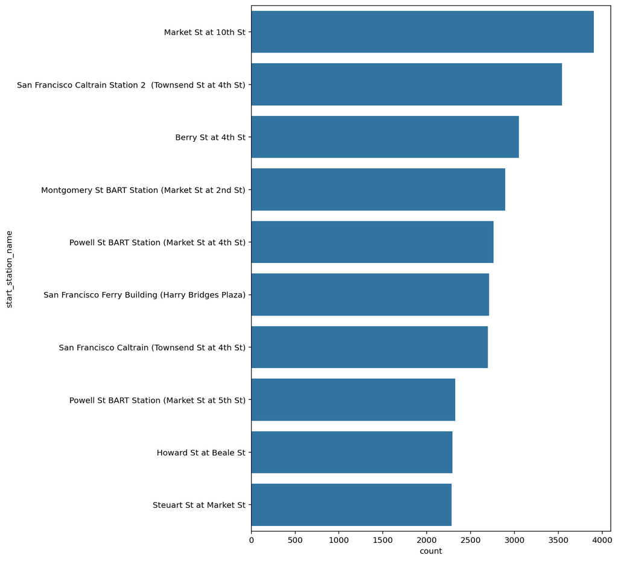

```python
#df["start_station_name"].value_counts()[:10]
print(df["start_station_name"].value_counts()[:10])
plt.figure(figsize = (8,12))
sns.countplot(data = df, y = 'start_station_name', order = df["start_station_name"].value_counts()[:10].index, color = sns.color_palette()[0]);
```

- Showing the top 10 most used "Start-Station"

### End station

```
San Francisco Caltrain Station 2  (Townsend St at 4th St)    4854
Market St at 10th St                                         3973
Montgomery St BART Station (Market St at 2nd St)             3646
San Francisco Ferry Building (Harry Bridges Plaza)           3368
Powell St BART Station (Market St at 4th St)                 2997
San Francisco Caltrain (Townsend St at 4th St)               2937
Berry St at 4th St                                           2871
The Embarcadero at Sansome St                                2512
Powell St BART Station (Market St at 5th St)                 2353
Steuart St at Market St                                      2338
Name: end_station_name, dtype: int64
```

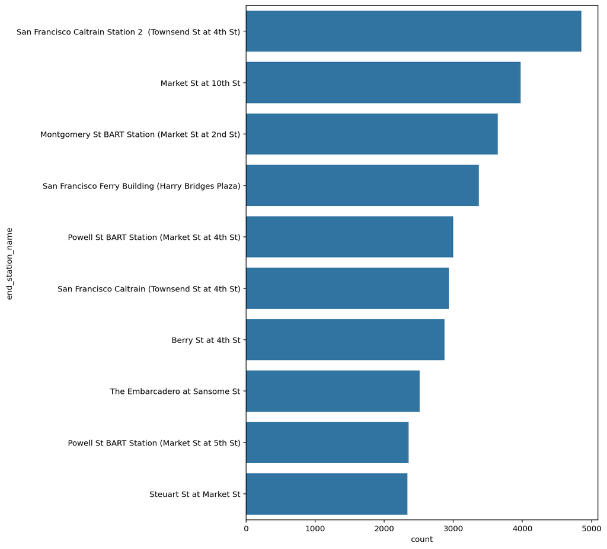

```python
#df["end_station_name"].value_counts()[:10]
print(df["end_station_name"].value_counts()[:10])
plt.figure(figsize = (8,12))
sns.countplot(data = df, y = 'end_station_name', order = df["end_station_name"].value_counts()[:10].index, color = sns.color_palette()[0]);
```

- Showing the top 10 most used "end-station"

### Time

```python
df['duration_sec'].describe()
```

```
count    183334.000000
mean        726.111245
std        1794.746219
min          61.000000
25%         325.000000
50%         514.000000
75%         796.000000
max       85444.000000
Name: duration_sec, dtype: float64
```

```python
df.query('duration_sec <= 1000').shape
```

```
(155770, 17)
```

```python
df['duration_sec'].nlargest(4000)
```

```
101361    85444
85465     84548
153705    83772
127999    83519
112435    83407
          ...
35455      2282
45674      2282
89859      2282
92956      2282
153249     2282
Name: duration_sec, Length: 4000, dtype: int64
```

```python
df2 = df.copy()
df2 = df2.query('duration_sec <= 1000')
```

```python
df2.shape
```

```
(155770, 17)
```

```python
df2.shape[0] / df.shape[0]
```

```
0.8496514558128879
```

```python
df2['duration_sec'].describe()
```

```
count    155770.000000
mean        482.262952
std         227.340886
min          61.000000
25%         298.000000
50%         453.000000
75%         648.000000
max        1000.000000
Name: duration_sec, dtype: float64
```

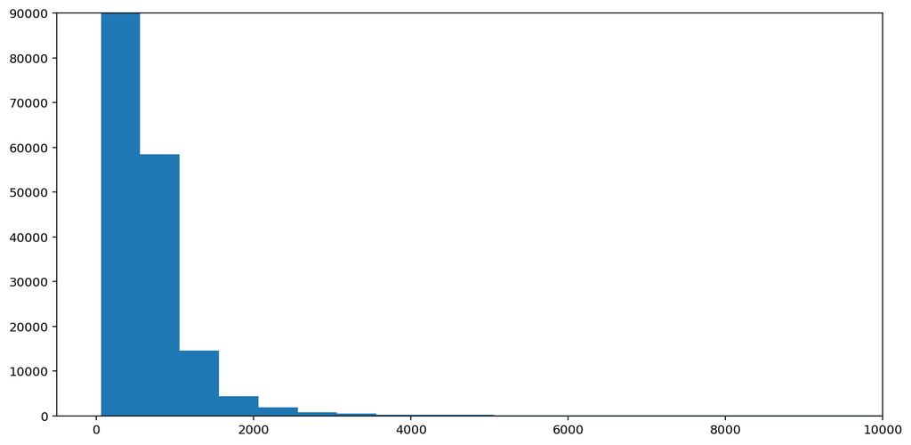

```python
bins = np.arange(61, df['duration_sec'].max() + 500, 500)

plt.figure(figsize=[12, 6])
plt.hist(df['duration_sec'], bins = bins)
plt.axis([-500, 10000, 0, 90000])
plt.show()
```

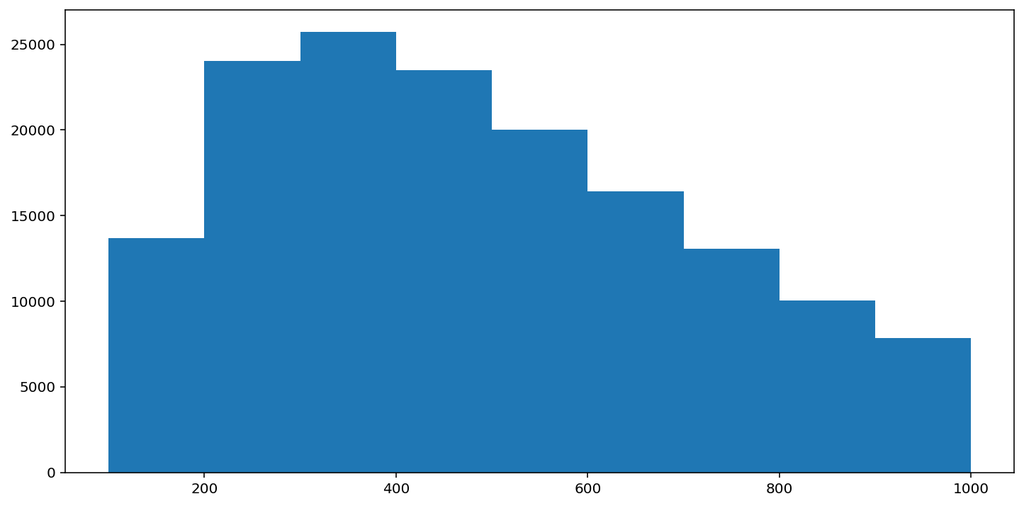

```python
bins = np.arange(100, df2['duration_sec'].max() + 100, 100)

plt.figure(figsize=[12, 6])
plt.hist(df['duration_sec'], bins = bins)
#plt.axis([0, 1000, 0, 2600])
plt.show()
```

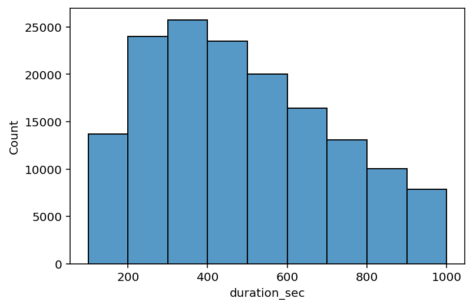

```python
sns.histplot(data = df2, x = 'duration_sec',binrange = [100, 1000], binwidth = 100);
```

- Same histogram, but with seaborn

### Discuss the distribution(s) of your variable(s) of interest. Were there any unusual points? Did you need to perform any transformations?

> - The duration in secs of the trips are most of them in between 200 to 1000...meaning that most trip are less then 15 minutes! Which makes a lot of sense because this service works with single rides (up to 30 minutes);
> - We had a lot more males using this services;
> - A LOT more subscribers than normal customers.

### Of the features you investigated, were there any unusual distributions? Did you perform any operations on the data to tidy, adjust, or change the form of the data? If so, why did you do this?

> - The main feature that i adjusted was the duration of the rent, where the only thing that i did was to "cut" the 15% highest values, because 85% of the trips were below 1000 secs;
> - The other thing i could have addressed was about the age, just subtract the birth year with the actual year...but i at the end i just leave as it is.

# Bivariate Exploration

### Duration and Age

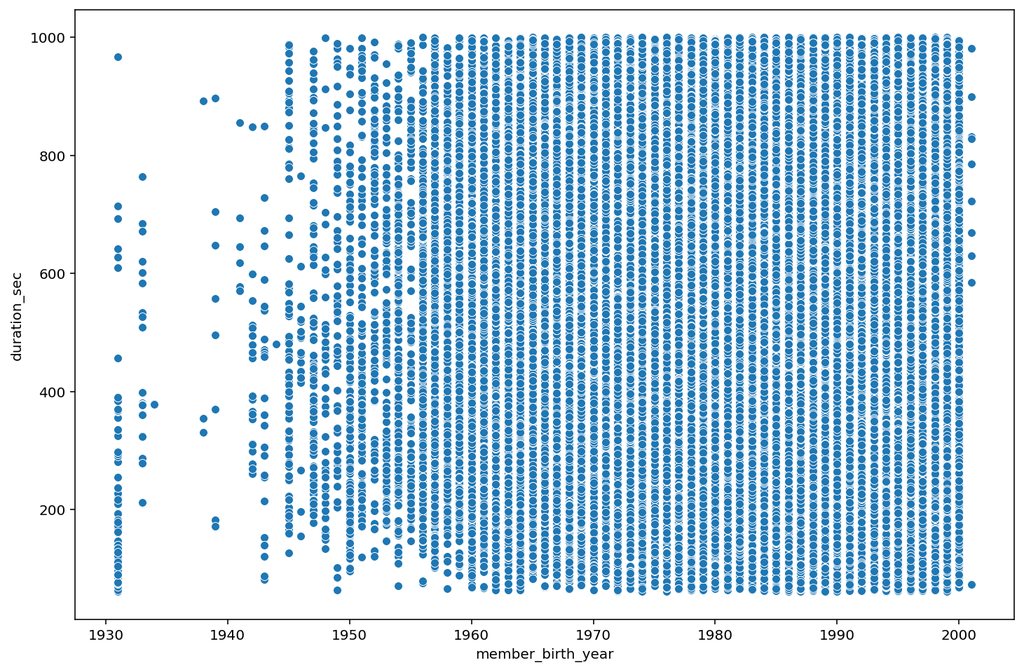

```python
plt.figure(figsize = (12,8))
sns.scatterplot(data = df2, y = "duration_sec", x = "member_birth_year");
```

- Coparing the duration of the trip and the birth year...there is too much data and we can see that its distributed almost the same for every age

### Gender and duration

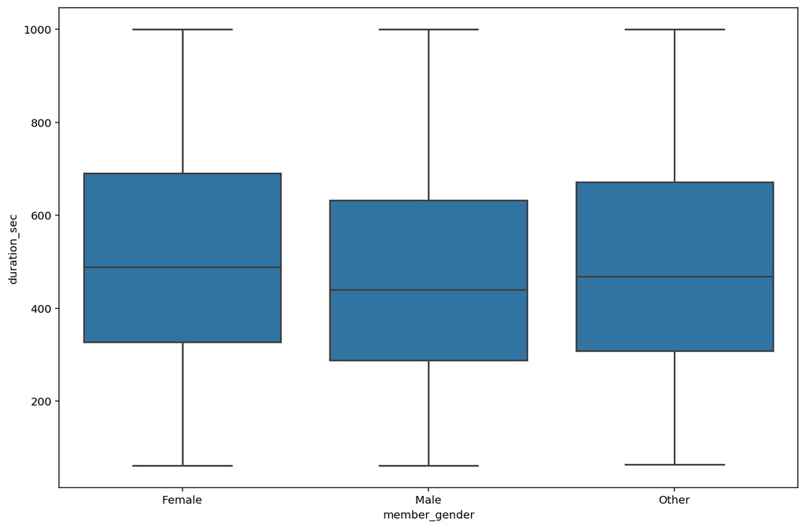

```python
plt.figure(figsize = (12,8))
sns.boxplot(data = df2, x = 'member_gender', y = 'duration_sec', color = sns.color_palette()[0]);
```

- Gender and duration, we can see that female are taking longer trips

### Birth year by weekdays

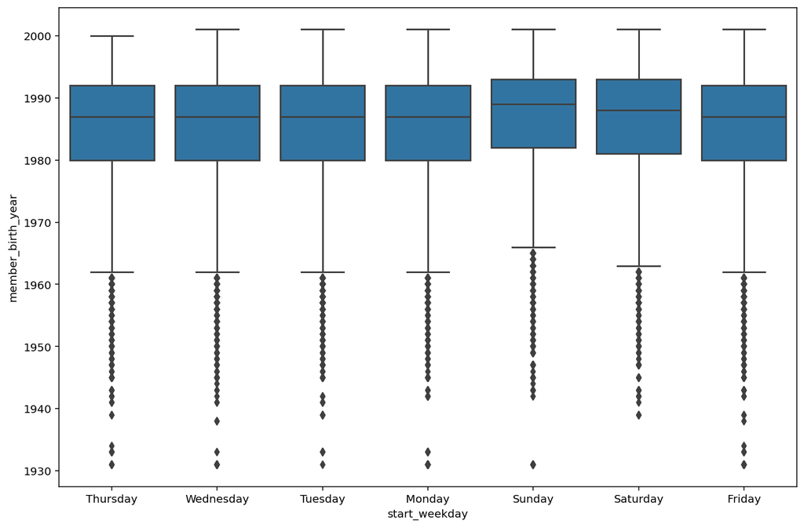

```python
plt.figure(figsize = (12,8))
sns.boxplot(data = df, x = 'start_weekday', y = 'member_birth_year', color = sns.color_palette()[0]);
```

### Subscription by birth year

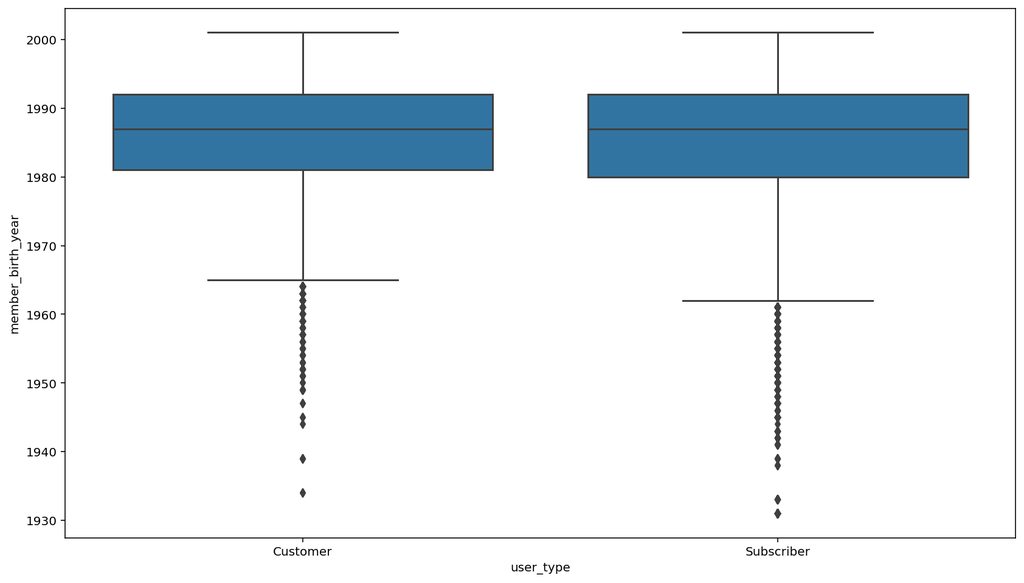

```python
plt.figure(figsize = (14,8))
sns.boxplot(data = df, x = 'user_type', y = 'member_birth_year', color = sns.color_palette()[0]);
```

- There is nothing really intersting in this plot, almost the same age for both

### Day of the week and gender

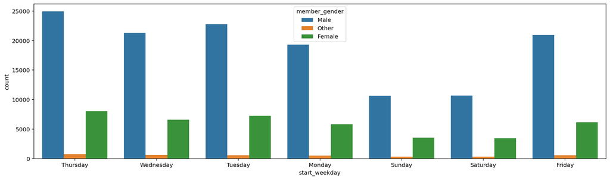

```python
plt.figure(figsize = [18, 5]);
sns.countplot(data = df, x = 'start_weekday', hue = 'member_gender');
```

- Gender, and weekdays...this was expected because we have a lot moer male users!

### Pair grid

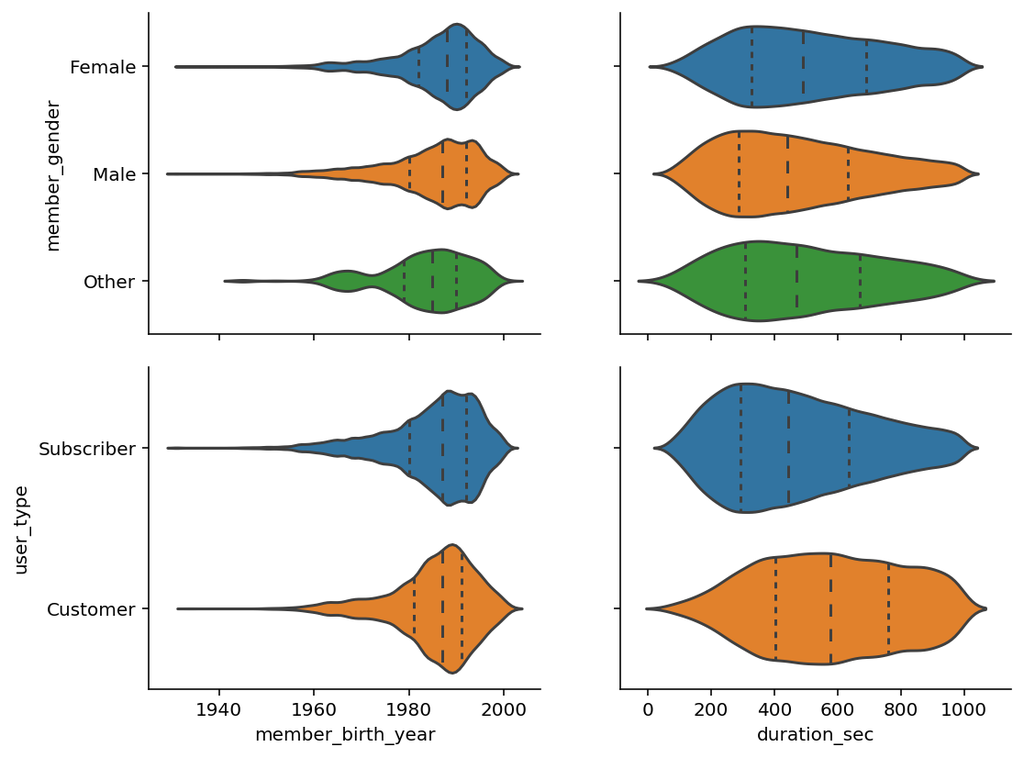

```python
g = sns.PairGrid(data = df2, x_vars = ['member_birth_year', 'duration_sec'], y_vars = ['member_gender','user_type']);
g.fig.set_size_inches(8,6)
g.map(sns.violinplot, inner = 'quartile');
```

- I did this one just out of curiosity! We have some plots that i already did (user type by age), but we plotted some intersting ones like the user type and duration of the trip!

### Talk about some of the relationships you observed in this part of the investigation. How did the feature(s) of interest vary with other features in the dataset?

> Most of the plots told me things that i already expected, with the subscribers and gender...but the ones with duration were really useful!

### Did you observe any interesting relationships between the other features (not the main feature(s) of interest)?

> Probably the duration in seconds and the user type (Subscriber or customer), the plot show us that the subscrivers are making smaller trips (at least in the dataframe with trips < 1000 secs).

# Multivariate Exploration

### Gender, user type and duration

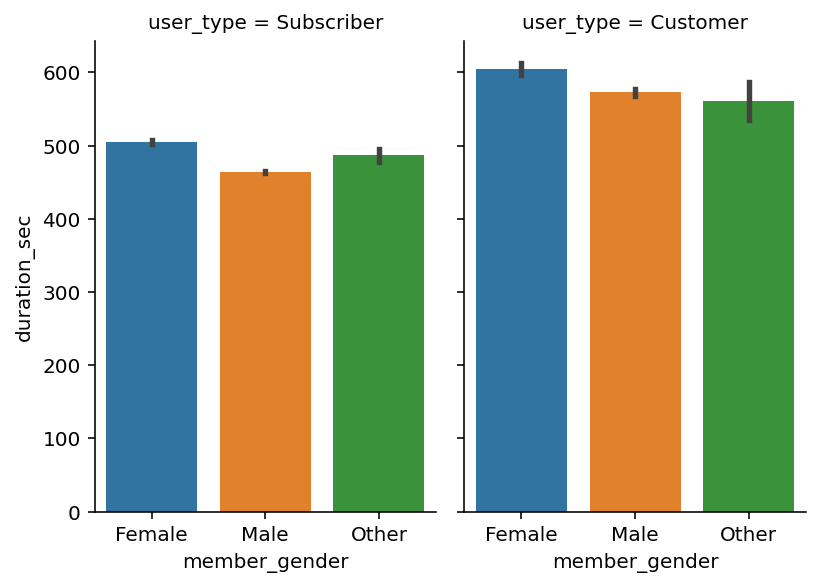

```python
sns.catplot(x = "member_gender", y = "duration_sec",
                col = "user_type",
                data = df2, kind = "bar",
                height=4, aspect=.7);
```

- We plotted this on the bivariate but separated, now we have user type gender and the duration in secs of them!

### Weekday, user type and duration

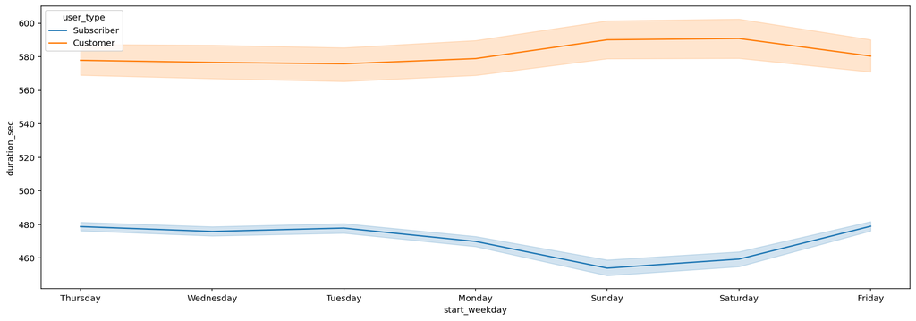

```python
plt.figure(figsize = (18,6))
sns.lineplot(data = df2, x = 'start_weekday', y = 'duration_sec', hue = 'user_type');
```

- This lines just show us the duration in secs of the trips through the weekend, we can see that on sunday the subs are making trips with less duration and the normal customer longer trips!

### Duration, weekday and most frequented stations

```python
df3 = df2.copy()
```

```python
df3["start_station_name"].value_counts()[:10]
```

```
Market St at 10th St                                         3603
San Francisco Caltrain Station 2  (Townsend St at 4th St)    3244
Berry St at 4th St                                           2738
Montgomery St BART Station (Market St at 2nd St)             2484
San Francisco Caltrain (Townsend St at 4th St)               2420
Powell St BART Station (Market St at 4th St)                 2296
San Francisco Ferry Building (Harry Bridges Plaza)           2091
Howard St at Beale St                                        2045
Powell St BART Station (Market St at 5th St)                 1963
Steuart St at Market St                                      1939
Name: start_station_name, dtype: int64
```

```python
lista = df3["start_station_name"].value_counts()[:10].index
lista
```

```
Index(['Market St at 10th St',
       'San Francisco Caltrain Station 2  (Townsend St at 4th St)',
       'Berry St at 4th St',
       'Montgomery St BART Station (Market St at 2nd St)',
       'San Francisco Caltrain (Townsend St at 4th St)',
       'Powell St BART Station (Market St at 4th St)',
       'San Francisco Ferry Building (Harry Bridges Plaza)',
       'Howard St at Beale St', 'Powell St BART Station (Market St at 5th St)',
       'Steuart St at Market St'],
      dtype='object')
```

```python
len(lista)
```

```
10
```

```python
df3 = df3[df3['start_station_name'].isin(lista)]
```

```python
df3.shape
```

```
(24823, 17)
```

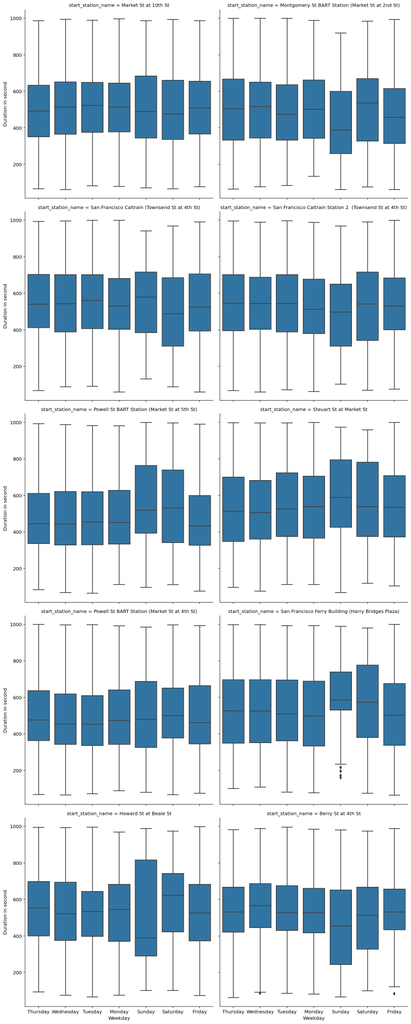

```python
g = sns.FacetGrid(df3, col = "start_station_name", col_wrap = 2, height = 6)
g.map_dataframe(sns.boxplot, x = "start_weekday", y = "duration_sec")
g.set_axis_labels("Weekday", "Duration in second")
```

- This plot show us the relation to the trip duration, weekdays and the top 10 most used stations...i plotted this mainly because i wanted to see if there was any station with really big duration, maybe because it was far away...i dont know.

#### Saving at a new csv to use later

```python
df.head()
```

|  | duration_sec | start_time | end_time | start_station_id | start_station_name | start_station_latitude | start_station_longitude | end_station_id | end_station_name | end_station_latitude | end_station_longitude | bike_id | user_type | member_birth_year | member_gender | bike_share_for_all_trip | start_weekday |
| --- | --- | --- | --- | --- | --- | --- | --- | --- | --- | --- | --- | --- | --- | --- | --- | --- | --- |
| 0 | 52185 | 2019-02-28 17:32:10.145 | 2019-03-01 08:01:55.975 | 21.0 | Montgomery St BART Station (Market St at 2nd St) | 37.789625 | -122.400811 | 13.0 | Commercial St at Montgomery St | 37.794231 | -122.402923 | 4902 | Customer | 1984.0 | Male | No | Thursday |
| 1 | 42521 | 2019-02-28 18:53:21.789 | 2019-03-01 06:42:03.056 | 23.0 | The Embarcadero at Steuart St | 37.791464 | -122.391034 | 81.0 | Berry St at 4th St | 37.775880 | -122.393170 | 2535 | Customer | NaN | NaN | No | Thursday |
| 2 | 61854 | 2019-02-28 12:13:13.218 | 2019-03-01 05:24:08.146 | 86.0 | Market St at Dolores St | 37.769305 | -122.426826 | 3.0 | Powell St BART Station (Market St at 4th St) | 37.786375 | -122.404904 | 5905 | Customer | 1972.0 | Male | No | Thursday |
| 3 | 36490 | 2019-02-28 17:54:26.010 | 2019-03-01 04:02:36.842 | 375.0 | Grove St at Masonic Ave | 37.774836 | -122.446546 | 70.0 | Central Ave at Fell St | 37.773311 | -122.444293 | 6638 | Subscriber | 1989.0 | Other | No | Thursday |
| 4 | 1585 | 2019-02-28 23:54:18.549 | 2019-03-01 00:20:44.074 | 7.0 | Frank H Ogawa Plaza | 37.804562 | -122.271738 | 222.0 | 10th Ave at E 15th St | 37.792714 | -122.248780 | 4898 | Subscriber | 1974.0 | Male | Yes | Thursday |

```python
df.to_csv('slide.csv', index=False)
```

```python
df2.to_csv('slide2.csv', index=False)
```